# Methods

SVM, support vector machines, is a relatively Modern simple Supervised Machine Learning Algorithm used for classification and/or regression.

The following figure is a typical example of SVM.

[figure not shown]

SVM has three parameters, namely gamma, kernel and C.

The advantage of SVM is that it is very versatile, because we can use different types of kernels and different kernel parameters for specific data, and we can use SVM methods for both low-dimensional and high-dimensional data.

SVM also has some disadvantages, such as productivity decreases as the size of the training set increases and does not provide direct probability estimates.

```python
import pandas as pd
import seaborn as sns
import matplotlib.pyplot as plt
from sklearn import tree
from IPython.display import Image
import numpy as np
from collections import Counter
from sklearn.metrics import precision_recall_fscore_support
from sklearn.feature_extraction.text import CountVectorizer
from sklearn.metrics import confusion_matrix,accuracy_score,precision_score, recall_score, ConfusionMatrixDisplay
from sklearn.svm import SVC
```

# Class Distribution

```python
df = pd.read_csv("twitter_data_clean.csv")
df.rename({"Whether the relevant": "relevance"}, axis =1, inplace = True)

print("shape of the data", df.shape)
```

```
shape of the data (200, 5)
```

Processing Data

```python
vectorizer = CountVectorizer()

vectorizer.fit(df["text"])
temp = vectorizer.transform(df["text"])
bag_of_words = pd.DataFrame(temp.toarray(), columns = vectorizer.get_feature_names())

df = pd.concat([bag_of_words,df], axis =1)
df.drop(columns=["text","created_at"], inplace = True)
df.head()
```

|  | abdulaziz | able | ableism | abolishing | absorbing | academy | accept | access | accidently | account | ... | zh | zichal | zj | znbgk | zoa | zodiac | zplmaegx | favorite_count | retweet_count | relevance |
| --- | --- | --- | --- | --- | --- | --- | --- | --- | --- | --- | --- | --- | --- | --- | --- | --- | --- | --- | --- | --- | --- |
| 0 | 0 | 0 | 1 | 0 | 0 | 0 | 0 | 0 | 0 | 0 | ... | 0 | 0 | 0 | 0 | 0 | 0 | 0 | 0 | 0 | 0 |
| 1 | 0 | 0 | 0 | 0 | 0 | 0 | 0 | 0 | 0 | 0 | ... | 0 | 0 | 0 | 0 | 0 | 0 | 0 | 0 | 0 | 1 |
| 2 | 0 | 0 | 0 | 0 | 0 | 0 | 0 | 0 | 0 | 0 | ... | 0 | 0 | 0 | 0 | 0 | 0 | 0 | 2 | 0 | 0 |
| 3 | 0 | 0 | 0 | 0 | 0 | 0 | 0 | 0 | 0 | 0 | ... | 0 | 0 | 0 | 0 | 0 | 0 | 0 | 0 | 0 | 0 |
| 4 | 0 | 0 | 0 | 0 | 0 | 0 | 0 | 0 | 0 | 0 | ... | 0 | 0 | 0 | 0 | 0 | 0 | 0 | 0 | 0 | 0 |

5 rows × 1949 columns

Compute distribution of class labels

```python
num_0 = df["relevance"].value_counts()[0]
num_1 = df["relevance"].value_counts()[1]
print("Number of points with target=0:", num_0, num_0/(num_0+num_1)*100, "%")
print("Number of points with target=1:", num_1, num_1/(num_0+num_1)*100, "%")
```

```
Number of points with target=0: 120 60.0 %
Number of points with target=1: 80 40.0 %
```

# Baseline Model for comparison

```python
## RANDOM CLASSIFIER
def random_classifier(y_data):
    ypred=[];
    max_label=np.max(y_data); #print(max_label)
    for i in range(0,len(y_data)):
        ypred.append(int(np.floor((max_label+1)*np.random.uniform(0,1))))

    print("-----RANDOM CLASSIFIER-----")
    print("count of prediction:",Counter(ypred).values()) # counts the elements' frequency
    print("probability of prediction:",np.fromiter(Counter(ypred).values(), dtype=float)/len(y_data)) # counts the elements' frequency
    print("accuracy",accuracy_score(y_data, ypred))
    print("percision, recall, fscore,",precision_recall_fscore_support(y_data, ypred))
```

```python
random_classifier(df["relevance"])
```

```
-----RANDOM CLASSIFIER-----
count of prediction: dict_values([102, 98])
probability of prediction: [0.51 0.49]
accuracy 0.45
percision, recall, fscore, (array([0.54901961, 0.34693878]), array([0.46666667, 0.425     ]), array([0.5045045 , 0.38202247]), array([120,  80], dtype=int64))
```

# Feature Selection

https://scikit-learn.org/stable/modules/feature_selection.html#feature-selection

```python
X = df.loc[:, df.columns !="relevance"]
Y = df["relevance"]
```

```python
from sklearn.feature_selection import VarianceThreshold

sel = VarianceThreshold(threshold=(.05))
chosen_x = sel.fit_transform(X)
```

```python
print("we have following features left after removing los variance words:",chosen_x.shape[1])
concol = sel.get_feature_names_out()
print(concol)
X = pd.DataFrame(chosen_x, columns = concol)
```

```
we have following features left after removing los variance words: 38
['although' 'amp' 'billion' 'change' 'co' 'day' 'dojo' 'energy' 'future'
 'get' 'good' 'green' 'high' 'https' 'inflation' 'life' 'like' 'many'
 'mars' 'need' 'needs' 'new' 'nuclear' 'one' 'people' 'power' 'put' 'rare'
 'renewable' 'see' 'still' 'think' 'time' 'world' 'would' 'years'
 'favorite_count' 'retweet_count']
```

Spliting data set

```python
x_train = X.sample(frac=0.8, axis=0)
x_test = X.drop(x_train.index)

y_train = Y.iloc[x_train.index]
y_test = Y.drop(x_train.index)
```

# Model Tuning

```python
#Base Line:

SVM = SVC()
model = SVM.fit(x_train,y_train)

yp_train=model.predict(x_train)
yp_test=model.predict(x_test)

# print(y_pred.shape)
print([accuracy_score(y_test, yp_test),recall_score(y_test, yp_test,pos_label=0),recall_score(y_test, yp_test,pos_label=1)])
print([accuracy_score(y_train, yp_train),recall_score(y_train, yp_train,pos_label=0),recall_score(y_train, yp_train,pos_label=1)])
```

```
[0.6, 1.0, 0.0]
[0.6125, 1.0, 0.03125]
```

The above is bad, having 0 recall for label =1 in test. True pos/actual pos.

```python
from sklearn.model_selection import GridSearchCV

# defining parameter range
param_grid = {
              'gamma': [1, 0.1, 0.01, 0.001, 0.0001],
              'kernel': ['linear', 'poly', 'rbf', 'sigmoid']}

grid = GridSearchCV(SVC(), param_grid, refit = True, verbose = 3)

# fitting the model for grid search
grid.fit(x_train, y_train)
```

```
Fitting 5 folds for each of 20 candidates, totalling 100 fits
[CV 1/5] END ............gamma=1, kernel=linear;, score=0.688 total time=   0.0s
[CV 2/5] END ............gamma=1, kernel=linear;, score=0.719 total time=   0.0s
[CV 3/5] END ............gamma=1, kernel=linear;, score=0.781 total time=   0.0s
[CV 4/5] END ............gamma=1, kernel=linear;, score=0.875 total time=   0.0s
[CV 5/5] END ............gamma=1, kernel=linear;, score=0.812 total time=   0.0s
[CV 1/5] END ..............gamma=1, kernel=poly;, score=0.750 total time=   0.0s
[CV 2/5] END ..............gamma=1, kernel=poly;, score=0.719 total time=   0.0s
[CV 3/5] END ..............gamma=1, kernel=poly;, score=0.719 total time=   0.0s
[CV 4/5] END ..............gamma=1, kernel=poly;, score=0.812 total time=   0.0s
[CV 5/5] END ..............gamma=1, kernel=poly;, score=0.875 total time=   0.0s
[CV 1/5] END ...............gamma=1, kernel=rbf;, score=0.781 total time=   0.0s
[CV 2/5] END ...............gamma=1, kernel=rbf;, score=0.688 total time=   0.0s
[CV 3/5] END ...............gamma=1, kernel=rbf;, score=0.781 total time=   0.0s
[CV 4/5] END ...............gamma=1, kernel=rbf;, score=0.625 total time=   0.0s
[CV 5/5] END ...............gamma=1, kernel=rbf;, score=0.719 total time=   0.0s
[CV 1/5] END ...........gamma=1, kernel=sigmoid;, score=0.562 total time=   0.0s
[CV 2/5] END ...........gamma=1, kernel=sigmoid;, score=0.562 total time=   0.0s
[CV 3/5] END ...........gamma=1, kernel=sigmoid;, score=0.562 total time=   0.0s
[CV 4/5] END ...........gamma=1, kernel=sigmoid;, score=0.562 total time=   0.0s
[CV 5/5] END ...........gamma=1, kernel=sigmoid;, score=0.594 total time=   0.0s
[CV 1/5] END ..........gamma=0.1, kernel=linear;, score=0.688 total time=   0.0s
[CV 2/5] END ..........gamma=0.1, kernel=linear;, score=0.719 total time=   0.0s
[CV 3/5] END ..........gamma=0.1, kernel=linear;, score=0.781 total time=   0.0s
[CV 4/5] END ..........gamma=0.1, kernel=linear;, score=0.875 total time=   0.0s
[CV 5/5] END ..........gamma=0.1, kernel=linear;, score=0.812 total time=   0.0s
[CV 1/5] END ............gamma=0.1, kernel=poly;, score=0.750 total time=   0.0s
[CV 2/5] END ............gamma=0.1, kernel=poly;, score=0.719 total time=   0.0s
[CV 3/5] END ............gamma=0.1, kernel=poly;, score=0.719 total time=   0.0s
[CV 4/5] END ............gamma=0.1, kernel=poly;, score=0.750 total time=   0.0s
[CV 5/5] END ............gamma=0.1, kernel=poly;, score=0.781 total time=   0.0s
[CV 1/5] END .............gamma=0.1, kernel=rbf;, score=0.719 total time=   0.0s
[CV 2/5] END .............gamma=0.1, kernel=rbf;, score=0.719 total time=   0.0s
[CV 3/5] END .............gamma=0.1, kernel=rbf;, score=0.781 total time=   0.0s
[CV 4/5] END .............gamma=0.1, kernel=rbf;, score=0.719 total time=   0.0s
[CV 5/5] END .............gamma=0.1, kernel=rbf;, score=0.750 total time=   0.0s
[CV 1/5] END .........gamma=0.1, kernel=sigmoid;, score=0.594 total time=   0.0s
[CV 2/5] END .........gamma=0.1, kernel=sigmoid;, score=0.688 total time=   0.0s
[CV 3/5] END .........gamma=0.1, kernel=sigmoid;, score=0.719 total time=   0.0s
[CV 4/5] END .........gamma=0.1, kernel=sigmoid;, score=0.656 total time=   0.0s
```

[output cut: 46 more lines]

```
[CV 1/5] END .........gamma=0.0001, kernel=poly;, score=0.625 total time=   0.0s
[CV 2/5] END .........gamma=0.0001, kernel=poly;, score=0.625 total time=   0.0s
[CV 3/5] END .........gamma=0.0001, kernel=poly;, score=0.594 total time=   0.0s
[CV 4/5] END .........gamma=0.0001, kernel=poly;, score=0.594 total time=   0.0s
[CV 5/5] END .........gamma=0.0001, kernel=poly;, score=0.594 total time=   0.0s
[CV 1/5] END ..........gamma=0.0001, kernel=rbf;, score=0.625 total time=   0.0s
[CV 2/5] END ..........gamma=0.0001, kernel=rbf;, score=0.594 total time=   0.0s
[CV 3/5] END ..........gamma=0.0001, kernel=rbf;, score=0.594 total time=   0.0s
[CV 4/5] END ..........gamma=0.0001, kernel=rbf;, score=0.594 total time=   0.0s
[CV 5/5] END ..........gamma=0.0001, kernel=rbf;, score=0.594 total time=   0.0s
[CV 1/5] END ......gamma=0.0001, kernel=sigmoid;, score=0.625 total time=   0.0s
[CV 2/5] END ......gamma=0.0001, kernel=sigmoid;, score=0.594 total time=   0.0s
[CV 3/5] END ......gamma=0.0001, kernel=sigmoid;, score=0.594 total time=   0.0s
[CV 4/5] END ......gamma=0.0001, kernel=sigmoid;, score=0.594 total time=   0.0s
[CV 5/5] END ......gamma=0.0001, kernel=sigmoid;, score=0.594 total time=   0.0s
```

```
GridSearchCV(estimator=SVC(),
             param_grid={'gamma': [1, 0.1, 0.01, 0.001, 0.0001],
                         'kernel': ['linear', 'poly', 'rbf', 'sigmoid']},
             verbose=3)
```

```python
pa = grid.cv_results_['params']
```

```python
grid.cv_results_
```

[output not shown]

[output cut: 24 more lines]

[output not shown]

```python
# print best parameter after tuning
print(grid.best_params_)

# print how our model looks after hyper-parameter tuning
print(grid.best_estimator_)
```

```
{'gamma': 1, 'kernel': 'linear'}
SVC(gamma=1, kernel='linear')
```

```python
test_results=[]
train_results=[]

# kernel = ['linear', 'poly', 'rbf', 'sigmoid']
gamma = np.linspace(0.0001,1,20)

for i in range(len(gamma)):
    SVM = SVC(gamma = gamma[i])
    model = SVM.fit(x_train,y_train)

    yp_train=model.predict(x_train)
    yp_test=model.predict(x_test)

    # print(y_pred.shape)
    test_results.append([pa[i],accuracy_score(y_test, yp_test),recall_score(y_test, yp_test,pos_label=0),recall_score(y_test, yp_test,pos_label=1)])
    train_results.append([pa[i],accuracy_score(y_train, yp_train),recall_score(y_train, yp_train,pos_label=0),recall_score(y_train, yp_train,pos_label=1)])
```

```python
test_results = np.array(test_results)
train_results = np.array(train_results)
```

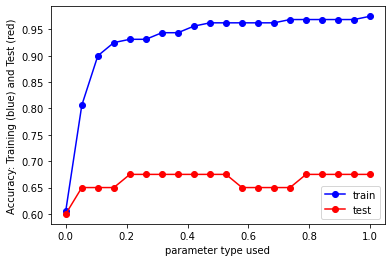

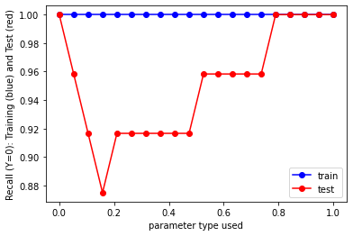

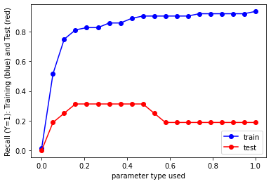

```python
x_axis = gamma
fig = plt.figure()
ax1 = fig.add_subplot(111)

ax1.plot(x_axis,train_results[:,1], c="b", marker='o',label = "train" )
ax1.plot(x_axis,test_results[:,1], c="r", marker='o',label = "test" )
plt.xlabel("parameter type used")
plt.ylabel("Accuracy: Training (blue) and Test (red)")
plt.legend()
plt.show()

fig = plt.figure()
ax1 = fig.add_subplot(111)

ax1.plot(x_axis,train_results[:,2], c="b", marker='o',label = "train" )
ax1.plot(x_axis,test_results[:,2], c="r", marker='o',label = "test" )
plt.xlabel("parameter type used")
plt.ylabel("Recall (Y=0): Training (blue) and Test (red)")
plt.legend()
plt.show()

fig = plt.figure()
ax3 = fig.add_subplot(111)

ax3.plot(x_axis,train_results[:,3], c="b", marker='o',label = "train" )
ax3.plot(x_axis,test_results[:,3], c="r", marker='o',label = "test" )
plt.xlabel("parameter type used")
plt.ylabel("Recall (Y=1): Training (blue) and Test (red)")
plt.legend()
plt.show()
```

# Final Results

```python
def confusion_plot(y_data,y_pred):
  print("ACCURACY:",accuracy_score(y_data, y_pred) )
  print("NEGATIVE RECALL (Y=0):", recall_score(y_data, y_pred, pos_label= 0))
  print("NEGATIVE PRECISION (Y=0):", precision_score(y_data, y_pred, pos_label= 0))
  print("POSITIVE RECALL (Y=1):", recall_score(y_data, y_pred, pos_label= 1))
  print("POSITIVE PRECISION (Y=1):", precision_score(y_data, y_pred, pos_label= 1))

  cm = confusion_matrix(y_data, y_pred, labels=model.classes_)
  disp = ConfusionMatrixDisplay(confusion_matrix=cm,display_labels=model.classes_)
  print(cm)

  disp.plot()
  plt.show()
```

```
------TRAINING------
ACCURACY: 0.9625
NEGATIVE RECALL (Y=0): 1.0
NEGATIVE PRECISION (Y=0): 0.9411764705882353
POSITIVE RECALL (Y=1): 0.90625
POSITIVE PRECISION (Y=1): 1.0
[[96  0]
 [ 6 58]]
```

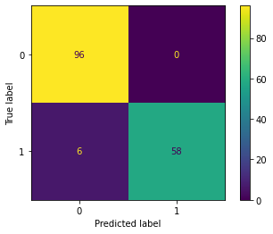

```
------TEST------
ACCURACY: 0.65
NEGATIVE RECALL (Y=0): 0.9583333333333334
NEGATIVE PRECISION (Y=0): 0.6388888888888888
POSITIVE RECALL (Y=1): 0.1875
POSITIVE PRECISION (Y=1): 0.75
[[23  1]
 [13  3]]
```

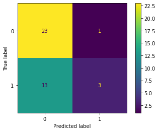

```python
# Using the parameter of 15
gamma = 0.6
SVM = SVC(gamma = gamma)
model = SVM.fit(x_train,y_train)

yp_train=model.predict(x_train)
yp_test=model.predict(x_test)

print("------TRAINING------")
confusion_plot(y_train,yp_train)
print("------TEST------")
confusion_plot(y_test,yp_test)
```

# Conclusion

We can see from the results of the final confusion matrix that there is some overfitting. This depends on the kernel we chose, because we did not set kernel and C when we set parameters, just gamma. We might get better results if we set the kernel to linear or something else.

In addition, the results are not very good, perhaps because our data volume is too small, only hundreds of tweets. If we have a larger amount of data, the effect of SVM may be better.

Nevertheless, we can see that SVM still has a high value for solving such problems, but we need to make some improvements on it in the future, especially in terms of parameters. Finding more suitable parameters for this problem may produce excellent results.